# EDA & Data Cleaning

# File management & projects: how to stop yourself from making a mess

If we want to import data into R, we need to tell R where to find the file we want to import. If we want to save our results, we need to tell R where to save them. In other words: we need some idea of where our files are (I assume you know at least [what they are](https://www.theverge.com/22684730/students-file-folder-directory-structure-education-gen-z)) or where they are “going”. The “classic” way to do this is to set a working directory using `setwd("path/to/my/files")`. You can see what your current working directory is using `getwd()` (run it on the console to check).

However, one of the pillars of science is reproducibility: if you hand in your thesis, or publish a paper, and someone wants to reproduce your results, and your code includes something like `setwd("Users/Me/Documents/Stuff/Uni/BA/FolderOnlyIHave/MoreStuff/")`, *No one* except you will be able to run it. Even worse, what if you import files only you have?

Solution: stay organized. [Here](https://alexd106.github.io/intro2R/project_setup.html) is a guide on how to set up a clean and reproducible project and use `.Rproj`ects, and [here](https://here.r-lib.org/) you can find the `here`-package, which allows you to side-step file path nightmares.

# Let’s work on some real data

```r
library(dplyr)
library(ggplot2)
# https://www.bfro.net/
bf <- readr::read_csv(here::here("data", "bigfoot.csv"))
```

We will investigate one of my personal research interests today: bigfoot. The data we use has been meticulously compiled by the [Bigfoot Field Researchers Organization (BFRO)](https://www.bfro.net/) and contains data on sightings with a classification (how reliable they are) and some additional data on location and circumstances of the sightings.

# Basics

The end-goal is to find out what circumstances predict reliable bigfoot-sightings (we are not looking for causal relationships here, just what correlates - this is not a research design or methods class). But first, we should spend some time exploring our data to get familiar with it, and tidy & clean it a bit.

## Exploratory Data Analysis (EDA)

First step is to get an overview of your data.

```r
tibble(bf)
```

```
#> # A tibble: 5,021 × 28
#>    observed        location_details county state season title latitude longitude
#>    <chr>           <chr>            <chr>  <chr> <chr>  <chr>    <dbl>     <dbl>
#>  1 "I was canoein…  <NA>            Winst… Alab… Summer <NA>      NA        NA
#>  2 "Ed L. was sal… "East side of P… Valde… Alas… Fall   <NA>      NA        NA
#>  3 "While attendi… "Great swamp ar… Washi… Rhod… Fall   Repo…     41.4     -71.5
#>  4 "Hello, My nam… "I would rather… York … Penn… Summer <NA>      NA        NA
#>  5 "It was May 19… "Logging roads … Yamhi… Oreg… Spring <NA>      NA        NA
#>  6 "My two childr… "The creature c… Washi… Okla… Fall   Repo…     35.3     -99.2
#>  7 "I was staying… "Vincent, Ohio … Washi… Ohio  Summer Repo…     39.4     -81.7
#>  8 "Well last yea… "Both sightings… Westc… New … Fall   Repo…     41.3     -73.7
#>  9 "I grew up in … "The Western fa… Washo… Neva… Fall   Repo…     39.6    -120.
#> 10 "heh i kinda f… "the road is of… Warre… New … Fall   <NA>      NA        NA
#> # ℹ 5,011 more rows
#> # ℹ 20 more variables: date <date>, number <dbl>, classification <chr>,
#> #   geohash <chr>, temperature_high <dbl>, temperature_mid <dbl>,
#> #   temperature_low <dbl>, dew_point <dbl>, humidity <dbl>, cloud_cover <dbl>,
#> #   moon_phase <dbl>, precip_intensity <dbl>, precip_probability <dbl>,
#> #   precip_type <chr>, pressure <dbl>, summary <chr>, uv_index <dbl>,
#> #   visibility <dbl>, wind_bearing <dbl>, wind_speed <dbl>
```

```r
glimpse(bf)
```

```
#> Rows: 5,021
#> Columns: 28
#> $ observed           <chr> "I was canoeing on the Sipsey river in Alabama. It …
#> $ location_details   <chr> NA, "East side of Prince William Sound", "Great swa…
#> $ county             <chr> "Winston County", "Valdez-Chitina-Whittier County",…
#> $ state              <chr> "Alabama", "Alaska", "Rhode Island", "Pennsylvania"…
#> $ season             <chr> "Summer", "Fall", "Fall", "Summer", "Spring", "Fall…
#> $ title              <chr> NA, NA, "Report 6496: Bicycling student has night e…
#> $ latitude           <dbl> NA, NA, 41.45000, NA, NA, 35.30110, 39.38745, 41.29…
#> $ longitude          <dbl> NA, NA, -71.50000, NA, NA, -99.17020, -81.67339, -7…
#> $ date               <date> NA, NA, 1974-09-20, NA, NA, 1973-09-28, 1971-08-01…
#> $ number             <dbl> 30680, 1261, 6496, 8000, 703, 9765, 4983, 31940, 56…
#> $ classification     <chr> "Class B", "Class A", "Class A", "Class B", "Class …
#> $ geohash            <chr> NA, NA, "drm5ucxrc0", NA, NA, "9y32z667yc", "dpjbj6…
#> $ temperature_high   <dbl> NA, NA, 78.17, NA, NA, 71.86, NA, 92.24, NA, NA, 74…
#> $ temperature_mid    <dbl> NA, NA, 73.425, NA, NA, 61.425, NA, 80.810, NA, NA,…
#> $ temperature_low    <dbl> NA, NA, 68.68, NA, NA, 50.99, NA, 69.38, NA, NA, 53…
#> $ dew_point          <dbl> NA, NA, 65.72, NA, NA, 51.03, NA, 67.34, 32.55, NA,…
#> $ humidity           <dbl> NA, NA, 0.86, NA, NA, 0.79, NA, 0.68, 0.45, NA, 0.7…
#> $ cloud_cover        <dbl> NA, NA, 0.86, NA, NA, 0.11, NA, 0.05, 0.00, NA, 0.6…
#> $ moon_phase         <dbl> NA, NA, 0.16, NA, NA, 0.07, NA, 0.76, 0.02, NA, 0.1…
#> $ precip_intensity   <dbl> NA, NA, 0.0000, NA, NA, NA, NA, 0.0000, 0.0000, NA,…
#> $ precip_probability <dbl> NA, NA, 0.00, NA, NA, NA, NA, 0.00, 0.00, NA, 0.70,…
#> $ precip_type        <chr> NA, NA, NA, NA, NA, "rain", NA, NA, NA, NA, "rain",…
#> $ pressure           <dbl> NA, NA, 1020.61, NA, NA, 1017.26, NA, 1016.80, 1012…
#> $ summary            <chr> NA, NA, "Foggy until afternoon.", NA, NA, "Partly c…
#> $ uv_index           <dbl> NA, NA, 4, NA, NA, 7, NA, 8, 8, NA, 6, 10, 6, 7, NA…
#> $ visibility         <dbl> NA, NA, 2.750, NA, NA, 10.000, NA, 6.922, 8.880, NA…
#> $ wind_bearing       <dbl> NA, NA, 198, NA, NA, 259, NA, 219, 285, NA, 262, 19…
#> $ wind_speed         <dbl> NA, NA, 6.92, NA, NA, 8.41, NA, 1.01, 4.01, NA, 0.4…
```

```r
names(bf)
```

```
#>  [1] "observed"           "location_details"   "county"
#>  [4] "state"              "season"             "title"
#>  [7] "latitude"           "longitude"          "date"
#> [10] "number"             "classification"     "geohash"
#> [13] "temperature_high"   "temperature_mid"    "temperature_low"
#> [16] "dew_point"          "humidity"           "cloud_cover"
#> [19] "moon_phase"         "precip_intensity"   "precip_probability"
#> [22] "precip_type"        "pressure"           "summary"
#> [25] "uv_index"           "visibility"         "wind_bearing"
#> [28] "wind_speed"
```

```r
bf |>
  count(state) |>
  arrange(desc(n))
```

```
#> # A tibble: 49 × 2
#>    state          n
#>    <chr>      <int>
#>  1 Washington   601
#>  2 California   417
#>  3 Ohio         303
#>  4 Florida      302
#>  5 Oregon       249
#>  6 Illinois     237
#>  7 Texas        230
#>  8 Michigan     216
#>  9 Missouri     158
#> 10 Colorado     127
#> # ℹ 39 more rows
```

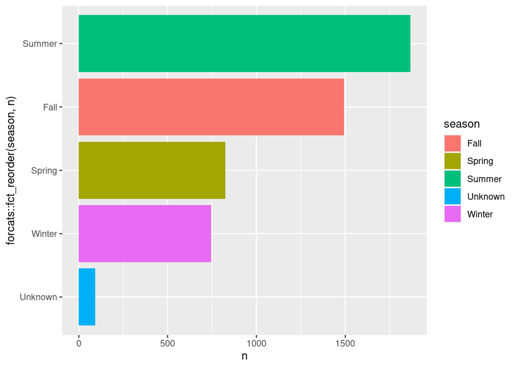

```r
bf |>
  count(season) |>
  ggplot(aes(x = n, y = forcats::fct_reorder(season, n), fill = season)) +
  # ^ a little trick to reorder your columns by size!
  geom_col()
```

Here, we encounter our first problem: what the heck is “Unknown”? We should probably investigate this a bit. Given we also have a column called “date”, maybe we can impute missing seasons based on the date?

## Cleaning

```r
bf |>
  filter(season == "Unknown") |>
  select(date, everything())
```

```
#> # A tibble: 92 × 28
#>    date       observed       location_details county state season title latitude
#>    <date>     <chr>          <chr>            <chr>  <chr> <chr>  <chr>    <dbl>
#>  1 1971-10-01 "It was in 19… Take I-77 to US… Yadki… Nort… Unkno… Repo…     36.1
#>  2 1979-07-18 "I was about … Near Hwy 43 on … Nash … Nort… Unkno… Repo…     36.0
#>  3 1980-06-30 "A man on a m… In Lincoln Nebr… Lanca… Nebr… Unkno… Repo…     40.8
#>  4 1957-09-18 "In 1957 in V… <NA>             Cherr… Nebr… Unkno… Repo…     42.9
#>  5 NA         "Many years a… <NA>             Coos … New … Unkno… <NA>      NA
#>  6 1992-01-15  <NA>          Near the line b… Stark… Ohio  Unkno… Repo…     40.8
#>  7 1997-05-01 "There was se… State Route 258… Tusca… Ohio  Unkno… Repo…     40.3
#>  8 1956-01-01 "Several thin… Vinton County, … Vinto… Ohio  Unkno… Repo…     39.3
#>  9 1962-06-06 "Rode my bike… Audobon Sanctua… Porta… Ohio  Unkno… Repo…     41.3
#> 10 1977-01-01 "While travel… This happened o… Defia… Ohio  Unkno… Repo…     41.3
#> # ℹ 82 more rows
#> # ℹ 20 more variables: longitude <dbl>, number <dbl>, classification <chr>,
#> #   geohash <chr>, temperature_high <dbl>, temperature_mid <dbl>,
#> #   temperature_low <dbl>, dew_point <dbl>, humidity <dbl>, cloud_cover <dbl>,
#> #   moon_phase <dbl>, precip_intensity <dbl>, precip_probability <dbl>,
#> #   precip_type <chr>, pressure <dbl>, summary <chr>, uv_index <dbl>,
#> #   visibility <dbl>, wind_bearing <dbl>, wind_speed <dbl>
```

```r
# ^ No, there are at least some dates for which we can impute the season!
```

If we are lazy, we can just convert the unknowns to `NA` (missing value, “Not Available”):

```r
bf |> mutate(season = na_if(season, "Unknown"))
```

```
#> # A tibble: 5,021 × 28
#>    observed        location_details county state season title latitude longitude
#>    <chr>           <chr>            <chr>  <chr> <chr>  <chr>    <dbl>     <dbl>
#>  1 "I was canoein…  <NA>            Winst… Alab… Summer <NA>      NA        NA
#>  2 "Ed L. was sal… "East side of P… Valde… Alas… Fall   <NA>      NA        NA
#>  3 "While attendi… "Great swamp ar… Washi… Rhod… Fall   Repo…     41.4     -71.5
#>  4 "Hello, My nam… "I would rather… York … Penn… Summer <NA>      NA        NA
#>  5 "It was May 19… "Logging roads … Yamhi… Oreg… Spring <NA>      NA        NA
#>  6 "My two childr… "The creature c… Washi… Okla… Fall   Repo…     35.3     -99.2
#>  7 "I was staying… "Vincent, Ohio … Washi… Ohio  Summer Repo…     39.4     -81.7
#>  8 "Well last yea… "Both sightings… Westc… New … Fall   Repo…     41.3     -73.7
#>  9 "I grew up in … "The Western fa… Washo… Neva… Fall   Repo…     39.6    -120.
#> 10 "heh i kinda f… "the road is of… Warre… New … Fall   <NA>      NA        NA
#> # ℹ 5,011 more rows
#> # ℹ 20 more variables: date <date>, number <dbl>, classification <chr>,
#> #   geohash <chr>, temperature_high <dbl>, temperature_mid <dbl>,
#> #   temperature_low <dbl>, dew_point <dbl>, humidity <dbl>, cloud_cover <dbl>,
#> #   moon_phase <dbl>, precip_intensity <dbl>, precip_probability <dbl>,
#> #   precip_type <chr>, pressure <dbl>, summary <chr>, uv_index <dbl>,
#> #   visibility <dbl>, wind_bearing <dbl>, wind_speed <dbl>
```

Dealing with missing values is generally something you will most likely have to do everytime with real data (respondents of surveys don’t answer questions or quit early, countries, organizations or businesses don’t report data, data is lost, etc. etc.).

Here, despite the hard work of the BFRO, we have a lot of missing values. Let’s find out how many there actually are. First, we can check for complete cases by omitting all rows with `NA`:

```r
bf |> na.omit()
```

```
#> # A tibble: 722 × 28
#>    observed        location_details county state season title latitude longitude
#>    <chr>           <chr>            <chr>  <chr> <chr>  <chr>    <dbl>     <dbl>
#>  1 "I was on my w… Close to Clarem… Sulli… New … Summer Repo…     43.4     -72.3
#>  2 "It was August… Waterloo Road, … Warre… New … Summer Repo…     40.9     -74.8
#>  3 "After getting… Wayne National … Washi… Ohio  Fall   Repo…     39.4     -81.4
#>  4 "I've told ver… In a developmen… Washi… Rhod… Summer Repo…     41.4     -71.7
#>  5 "I used to own… Approximately 4… Galla… Mont… Summer Repo…     45.8    -111.
#>  6 "Saw very larg… One (1) mile fr… Galla… Mont… Spring Repo…     45.6    -111.
#>  7 "I am an OTR t… Heading westbou… Miner… Mont… Spring Repo…     47.4    -116.
#>  8 "It has been a… It was in Monta… Misso… Mont… Summer Repo…     47.0    -114.
#>  9 "In mid july 2… We live just in… Misso… Mont… Summer Repo…     47.1    -114.
#> 10 "My family and… 8.6 miles up Fo… Misso… Mont… Summer Repo…     46.9    -114.
#> # ℹ 712 more rows
#> # ℹ 20 more variables: date <date>, number <dbl>, classification <chr>,
#> #   geohash <chr>, temperature_high <dbl>, temperature_mid <dbl>,
#> #   temperature_low <dbl>, dew_point <dbl>, humidity <dbl>, cloud_cover <dbl>,
#> #   moon_phase <dbl>, precip_intensity <dbl>, precip_probability <dbl>,
#> #   precip_type <chr>, pressure <dbl>, summary <chr>, uv_index <dbl>,
#> #   visibility <dbl>, wind_bearing <dbl>, wind_speed <dbl>
```

This shows only rows that have observations in *all* columns. But we may not need *aaaaall* columns, so let’s find out where the worst culprits are. We can do this by putting together some things you have already learned in the intro course (like defining functions):

```r
how_many_na <- function(vec) {
  sum(is.na(vec))
}
# ^ a function that takes a vector as input and
# returns the sum of NA values in the vector.

bf |> summarise(across(everything(), how_many_na))
```

```
#> # A tibble: 1 × 28
#>   observed location_details county state season title latitude longitude  date
#>      <int>            <int>  <int> <int>  <int> <int>    <int>     <int> <int>
#> 1       38              758      0     0      0   976      976       976   976
#> # ℹ 19 more variables: number <int>, classification <int>, geohash <int>,
#> #   temperature_high <int>, temperature_mid <int>, temperature_low <int>,
#> #   dew_point <int>, humidity <int>, cloud_cover <int>, moon_phase <int>,
#> #   precip_intensity <int>, precip_probability <int>, precip_type <int>,
#> #   pressure <int>, summary <int>, uv_index <int>, visibility <int>,
#> #   wind_bearing <int>, wind_speed <int>
```

```r
#^ Use `across()` to apply a function to multiple
# columns inside a dplyr-verb
```

The most radical approach to deal with missing values is to simply drop *all* of them:

```r
bf |> tidyr::drop_na()
```

```
#> # A tibble: 722 × 28
#>    observed        location_details county state season title latitude longitude
#>    <chr>           <chr>            <chr>  <chr> <chr>  <chr>    <dbl>     <dbl>
#>  1 "I was on my w… Close to Clarem… Sulli… New … Summer Repo…     43.4     -72.3
#>  2 "It was August… Waterloo Road, … Warre… New … Summer Repo…     40.9     -74.8
#>  3 "After getting… Wayne National … Washi… Ohio  Fall   Repo…     39.4     -81.4
#>  4 "I've told ver… In a developmen… Washi… Rhod… Summer Repo…     41.4     -71.7
#>  5 "I used to own… Approximately 4… Galla… Mont… Summer Repo…     45.8    -111.
#>  6 "Saw very larg… One (1) mile fr… Galla… Mont… Spring Repo…     45.6    -111.
#>  7 "I am an OTR t… Heading westbou… Miner… Mont… Spring Repo…     47.4    -116.
#>  8 "It has been a… It was in Monta… Misso… Mont… Summer Repo…     47.0    -114.
#>  9 "In mid july 2… We live just in… Misso… Mont… Summer Repo…     47.1    -114.
#> 10 "My family and… 8.6 miles up Fo… Misso… Mont… Summer Repo…     46.9    -114.
#> # ℹ 712 more rows
#> # ℹ 20 more variables: date <date>, number <dbl>, classification <chr>,
#> #   geohash <chr>, temperature_high <dbl>, temperature_mid <dbl>,
#> #   temperature_low <dbl>, dew_point <dbl>, humidity <dbl>, cloud_cover <dbl>,
#> #   moon_phase <dbl>, precip_intensity <dbl>, precip_probability <dbl>,
#> #   precip_type <chr>, pressure <dbl>, summary <chr>, uv_index <dbl>,
#> #   visibility <dbl>, wind_bearing <dbl>, wind_speed <dbl>
```

Or drop cases that have missing values in the columns you are interested in:

```r
bf |>
  filter(!is.na(season)) # ! = logical negation, reverses a lgl vector (just read as "not")
```

```
#> # A tibble: 5,021 × 28
#>    observed        location_details county state season title latitude longitude
#>    <chr>           <chr>            <chr>  <chr> <chr>  <chr>    <dbl>     <dbl>
#>  1 "I was canoein…  <NA>            Winst… Alab… Summer <NA>      NA        NA
#>  2 "Ed L. was sal… "East side of P… Valde… Alas… Fall   <NA>      NA        NA
#>  3 "While attendi… "Great swamp ar… Washi… Rhod… Fall   Repo…     41.4     -71.5
#>  4 "Hello, My nam… "I would rather… York … Penn… Summer <NA>      NA        NA
#>  5 "It was May 19… "Logging roads … Yamhi… Oreg… Spring <NA>      NA        NA
#>  6 "My two childr… "The creature c… Washi… Okla… Fall   Repo…     35.3     -99.2
#>  7 "I was staying… "Vincent, Ohio … Washi… Ohio  Summer Repo…     39.4     -81.7
#>  8 "Well last yea… "Both sightings… Westc… New … Fall   Repo…     41.3     -73.7
#>  9 "I grew up in … "The Western fa… Washo… Neva… Fall   Repo…     39.6    -120.
#> 10 "heh i kinda f… "the road is of… Warre… New … Fall   <NA>      NA        NA
#> # ℹ 5,011 more rows
#> # ℹ 20 more variables: date <date>, number <dbl>, classification <chr>,
#> #   geohash <chr>, temperature_high <dbl>, temperature_mid <dbl>,
#> #   temperature_low <dbl>, dew_point <dbl>, humidity <dbl>, cloud_cover <dbl>,
#> #   moon_phase <dbl>, precip_intensity <dbl>, precip_probability <dbl>,
#> #   precip_type <chr>, pressure <dbl>, summary <chr>, uv_index <dbl>,
#> #   visibility <dbl>, wind_bearing <dbl>, wind_speed <dbl>
```

For multiple columns:

```r
bf |>
  # Don't keep rows if they miss observations for
  # any of these two variables:
  filter(!if_any(c(season, uv_index), is.na))
```

```
#> # A tibble: 3,392 × 28
#>    observed        location_details county state season title latitude longitude
#>    <chr>           <chr>            <chr>  <chr> <chr>  <chr>    <dbl>     <dbl>
#>  1 "While attendi… Great swamp are… Washi… Rhod… Fall   Repo…     41.4     -71.5
#>  2 "My two childr… The creature cr… Washi… Okla… Fall   Repo…     35.3     -99.2
#>  3 "Well last yea… Both sightings … Westc… New … Fall   Repo…     41.3     -73.7
#>  4 "I grew up in … The Western fac… Washo… Neva… Fall   Repo…     39.6    -120.
#>  5 "I was on my w… Close to Clarem… Sulli… New … Summer Repo…     43.4     -72.3
#>  6 "I was northea… Latitude & Long… Thurs… Nebr… Spring Repo…     42.2     -96.3
#>  7 "While this in… Ward County, Ju… Ward … Nort… Spring Repo…     48.3    -101.
#>  8 "In early spri… Yancey County, … Yance… Nort… Spring Repo…     35.7     -82.3
#>  9 "The foot prin… At Bull Run Gul… Silve… Mont… Winter Repo…     46.1    -113.
#> 10 "I live in But… On the East Rid… Silve… Mont… Summer Repo…     46.0    -112.
#> # ℹ 3,382 more rows
#> # ℹ 20 more variables: date <date>, number <dbl>, classification <chr>,
#> #   geohash <chr>, temperature_high <dbl>, temperature_mid <dbl>,
#> #   temperature_low <dbl>, dew_point <dbl>, humidity <dbl>, cloud_cover <dbl>,
#> #   moon_phase <dbl>, precip_intensity <dbl>, precip_probability <dbl>,
#> #   precip_type <chr>, pressure <dbl>, summary <chr>, uv_index <dbl>,
#> #   visibility <dbl>, wind_bearing <dbl>, wind_speed <dbl>
```

Sometimes, however, you may have ways to impute your missing values. Let’s return to season: maybe we can impute the season based on the date, which we also have?

```r
bf |>
  filter(season == "Unknown") |>
  mutate(month = lubridate::month(date)) |>
  count(month)  # 28 can't be imputed...
```

```
#> # A tibble: 12 × 2
#>    month     n
#>    <dbl> <int>
#>  1     1    15
#>  2     2     1
#>  3     4     2
#>  4     5     6
#>  5     6    18
#>  6     7     4
#>  7     8     8
#>  8     9     3
#>  9    10     2
#> 10    11     4
#> 11    12     1
#> 12    NA    28
```

We can use `case_when()` to impute the “Unknowns”:

```r
bf <-
  bf |>
  mutate(
    month = lubridate::month(date),
    season = case_when(
      season != "Unknown" ~ season,
      month %in% c(3:5) ~ "Spring",
      month %in% c(6:9) ~ "Summer",
      month %in% c(10:11) ~ "Fall",
      month %in% c(12, 1, 2) ~ "Winter",
      .default = NA
    )
  )
```

`case_when()` is really handy: it’s basically a replacement for writing long chains of code like `if (condition) { do_something } else if (condition) { do_other_thing } else { do_this }`. The general formula for it is `case_when(condition ~ output)`. Lastly, we provide a default value for cases that match none of the `condition`s (here: `NA`).

## (Basic) modelling

[Classification Info](https://www.bfro.net/gdb/classify.asp)

Let’s first construct our outcome (a binary outcome for whether the sighting has been classified as “reliable” by the BFRO):

```r
bf <- bf |> mutate(reliable = if_else(classification == "Class A", 1, 0))
```

`if_else()` is similar to `case_when()`: the form is `if_else(condition, if_true_do_this, else_do_this)`; so if `classification == "Class A"` put a `1`, else put a `0`. We call the resulting vector `reliable`.

Fitting a model using `lm()` (“linear model”) from base R (you already saw this last week) & inspecting it:

```r
model <- lm(reliable ~ temperature_mid + humidity + moon_phase + cloud_cover + uv_index, data = bf)

summary(model)
```

```
#>
#> Call:
#> lm(formula = reliable ~ temperature_mid + humidity + moon_phase +
#>     cloud_cover + uv_index, data = bf)
#>
#> Residuals:
#>     Min      1Q  Median      3Q     Max
#> -0.5946 -0.4875 -0.4161  0.5074  0.6301
#>
#> Coefficients:
#>                   Estimate Std. Error t value Pr(>|t|)
#> (Intercept)      0.4871804  0.0625039   7.794 8.97e-15 ***
#> temperature_mid  0.0020073  0.0007772   2.583  0.00985 **
#> humidity        -0.1565479  0.0785783  -1.992  0.04644 *
#> moon_phase       0.0123151  0.0322445   0.382  0.70254
#> cloud_cover      0.0979714  0.0377374   2.596  0.00948 **
#> uv_index        -0.0091061  0.0050719  -1.795  0.07269 .
#> ---
#> Signif. codes:  0 '***' 0.001 '**' 0.01 '*' 0.05 '.' 0.1 ' ' 1
#>
#> Residual standard error: 0.4991 on 2882 degrees of freedom
#>   (2133 Beobachtungen als fehlend gelöscht)
#> Multiple R-squared:  0.005269,   Adjusted R-squared:  0.003543
#> F-statistic: 3.053 on 5 and 2882 DF,  p-value: 0.009409
```

A recipe to visualize your models:

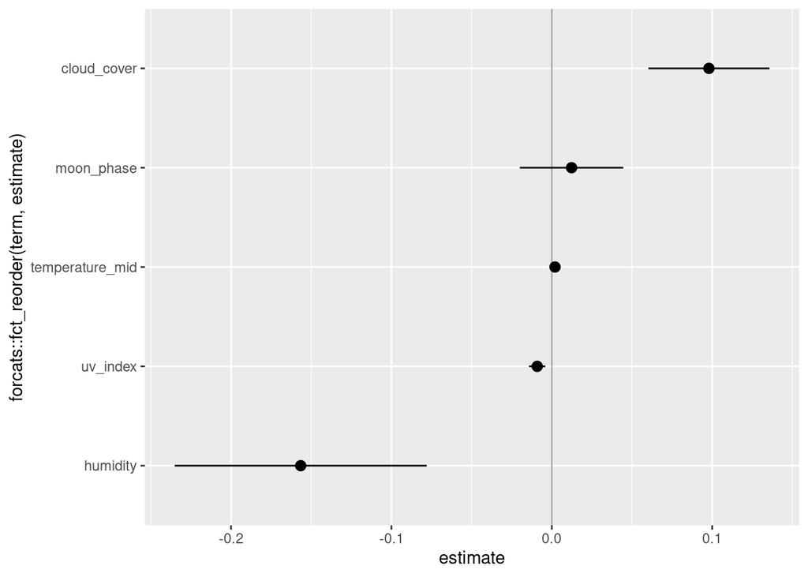

```r
model |>
  broom::tidy() |> # seen last week; turns model output into data frame
  mutate(lower = estimate - std.error, upper = estimate + std.error) |>
  filter(term != "(Intercept)") |>
  ggplot(aes(x = estimate, y = forcats::fct_reorder(term, estimate))) +
  geom_vline(xintercept = 0, color = "darkgrey") +
  geom_pointrange(aes(xmin = lower, xmax = upper))
```

One thing we have not discussed yet is string manipulation. Look at the y-axis labels: We may want to format the names a bit nicer. We can do this by modifying the strings (names) in the “term”-column:

```r
tidy_model <-
  model |>
  broom::tidy() |> # seen last week; turns model output into data frame
  mutate(lower = estimate - std.error, upper = estimate + std.error) |>
  filter(term != "(Intercept)")

tidy_model
```

```
#> # A tibble: 5 × 7
#>   term            estimate std.error statistic p.value    lower    upper
#>   <chr>              <dbl>     <dbl>     <dbl>   <dbl>    <dbl>    <dbl>
#> 1 temperature_mid  0.00201  0.000777     2.58  0.00985  0.00123  0.00278
#> 2 humidity        -0.157    0.0786      -1.99  0.0464  -0.235   -0.0780
#> 3 moon_phase       0.0123   0.0322       0.382 0.703   -0.0199   0.0446
#> 4 cloud_cover      0.0980   0.0377       2.60  0.00948  0.0602   0.136
#> 5 uv_index        -0.00911  0.00507     -1.80  0.0727  -0.0142  -0.00403
```

For everything with strings, use [`stringr`](https://stringr.tidyverse.org/):

```r
library(stringr)

tidy_model <-
  tidy_model |>
  mutate(
    term =
      term |> # take term, *and then...*
      # The syntax of stringr is quite intuitive:
      str_replace("_", " ") |>
      str_to_title() |>
      str_replace("Uv", "UV")
  )

tidy_model |> select(term)
```

```
#> # A tibble: 5 × 1
#>   term
#>   <chr>
#> 1 Temperature Mid
#> 2 Humidity
#> 3 Moon Phase
#> 4 Cloud Cover
#> 5 UV Index
```

Plotting again:

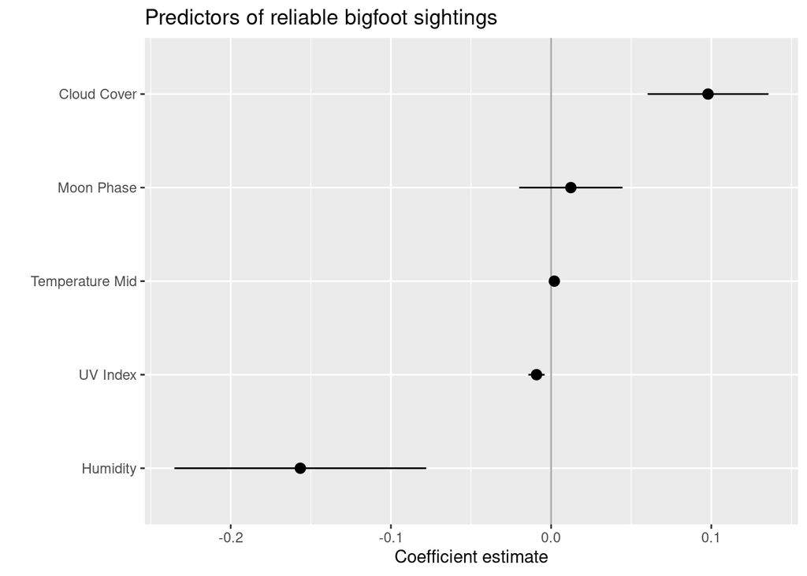

```r
tidy_model |>
  ggplot(aes(x = estimate, y = forcats::fct_reorder(term, estimate))) +
  geom_vline(xintercept = 0, color = "darkgrey") +
  geom_pointrange(aes(xmin = lower, xmax = upper)) +
  labs(x = "Coefficient estimate", y = "", title = "Predictors of reliable bigfoot sightings")
```

### Exporting your models

Check out `stargazer` and `modelsummary` if you want to export your results (to html, latex etc.)

```r
stargazer::stargazer(model, type="html")
```

|  | *Dependent variable:* |
| --- | --- |
|  | reliable |
| temperature_mid | 0.002*** |
|  | (0.001) |
| humidity | -0.157** |
|  | (0.079) |
| moon_phase | 0.012 |
|  | (0.032) |
| cloud_cover | 0.098*** |
|  | (0.038) |
| uv_index | -0.009* |
|  | (0.005) |
| Constant | 0.487*** |
|  | (0.063) |
| Observations | 2,888 |
| R<sup>2</sup> | 0.005 |
| Adjusted R<sup>2</sup> | 0.004 |
| Residual Std. Error | 0.499 (df = 2882) |
| F Statistic | 3.053*** (df = 5; 2882) |
| *Note:* | p<0.1; p<0.05; p<0.01 |

```r
model |>
  modelsummary::modelsummary(
    stars = c("***" = 0.01, "**" = 0.05, "*" = 0.1),
    coef_map = c(
      "temperature_mid" = "Temperature",
      "humidity" = "Humidity",
      "moon_phase" = "Moon Phase",
      "cloud_cover" = "Cloud Cover",
      "uv_index" = "UV Index"
    )
  ) |>
  kableExtra::add_header_above(c(" " = 1, "Reliable Sighting" = 1)) # = 1 column each
```

|  | Reliable Sighting (1) |
| --- | --- |
| Temperature | 0.002*** |
|  | (0.001) |
| Humidity | −0.157** |
|  | (0.079) |
| Moon Phase | 0.012 |
|  | (0.032) |
| Cloud Cover | 0.098*** |
|  | (0.038) |
| UV Index | −0.009* |
|  | (0.005) |
| Num.Obs. | 2888 |
| R2 | 0.005 |
| R2 Adj. | 0.004 |
| AIC | 4189.6 |
| BIC | 4231.4 |
| Log.Lik. | −2087.791 |
| F | 3.053 |
| RMSE | 0.50 |

* p < 0.1, ** p < 0.05, *** p < 0.01

If you have multiple models, just put them into a `list()`.

**Exercise Time:** Load the data on UFO sightings. Explore the data: look for issues with the data, patterns (seasonal, weather, locations, etc.) using dplyr verbs (e.g. `count()`, `filter()`, `arrange()` etc.).

*Suggestions:*

- Where are the most UFO sightings (what country? Restrict to US: which state? Which city?)
- What is the most common sighting (`shape`)?
- When did we see the most UFOs (e.g., which year or which month is most prominent)?

*Bonus:* Make a visualization! *Double Bonus:* Fit a simple linear model (`lm()`) & examine the output.

*Tips:* You can extract the year from a datetime using `lubridate::year()`, and the month using `lubdridate::month()` (use `label = TRUE` if you want the name, not the number of the month).

```r
ufo <- readr::read_csv(here::here("data/ufo_sightings.csv"))

# Your code here...
```

# Bonus: Put your brain on autopilot & let the computer make the model

[figure not shown]

In this case, we could also try to automate feature selection (i.e. selection of independent variables) to maximize explanatory power using stepwise AIC, which will select the best fit by minimizing [the AIC](https://en.wikipedia.org/wiki/Akaike_information_criterion).

We just slap all numeric variables we have into the model & let the computer do the rest:

```r
the_computers_model <-
  bf |>
  # just take all numeric variables except the ID (number):
  select(where(is.numeric), -number) |>
  # drop all rows with NA (or else conpuder will nag):
  tidyr::drop_na() |>
  lm(reliable ~ ., data = _) |>
  MASS::stepAIC(direction = "backward", trace = FALSE)
```

“Backward” means to start with all predictors & step by step remove those with the least significant effect (you can also do it “forward” which means starting with an empty model & gradually adding them, or “both”). The `trace`-argument controls whether all steps will be shown/printed.

As you may have thought already, this is basically just throwing spaghetti at the wall & seeing what sticks:

```r
stargazer::stargazer(the_computers_model, type = "html")
```

|  | *Dependent variable:* |
| --- | --- |
|  | reliable |
| latitude | -0.007*** |
|  | (0.002) |
| temperature_high | 0.013*** |
|  | (0.003) |
| temperature_mid | -0.013*** |
|  | (0.004) |
| cloud_cover | 0.169*** |
|  | (0.042) |
| pressure | 0.005*** |
|  | (0.002) |
| wind_bearing | -0.0003** |
|  | (0.0001) |
| wind_speed | 0.016*** |
|  | (0.004) |
| Constant | -4.724** |
|  | (1.951) |
| Observations | 2,112 |
| R<sup>2</sup> | 0.030 |
| Adjusted R<sup>2</sup> | 0.026 |
| Residual Std. Error | 0.493 (df = 2104) |
| F Statistic | 9.182*** (df = 7; 2104) |
| *Note:* | p<0.1; p<0.05; p<0.01 |

For example, there are two variables for temperature which probably capture the same thing. Looks like you will have to do the thinking yourself after all…

[figure not shown]